# Project1

# 2. What is the distribution of testosterone in the data set over age and how does it vary across BMI groups?

## Testosterone by Age Across BMI WHO Groups for Males

- Testosterone variable is total testosterone in nanograms per deciliter for participants aged 6 years or older for the years 2011-2012.
- Age is the age of the participant in 2011-2012, subjects who were 80 years or older were recorded as 80
- BMI WHO is the body mass index as categorized by the World Health Organization as 12.0-18.4 (underweight), 18.5-24.9 (normal weight), 25-29.9 (overweight), and 30 plus (Obese).

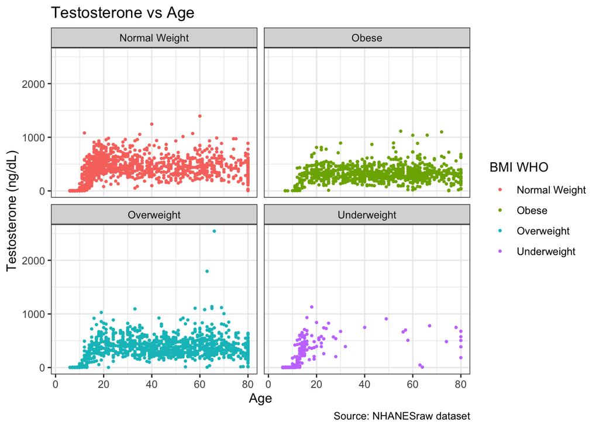

- Since the distributions are not normal, robust statistics are appropriate for better understanding the distributions.
- Median and interquartile range are used to accurately compare the spread of testosterone data by age group overtime.

## Median Testosterone by Age Across BMI WHO groups.

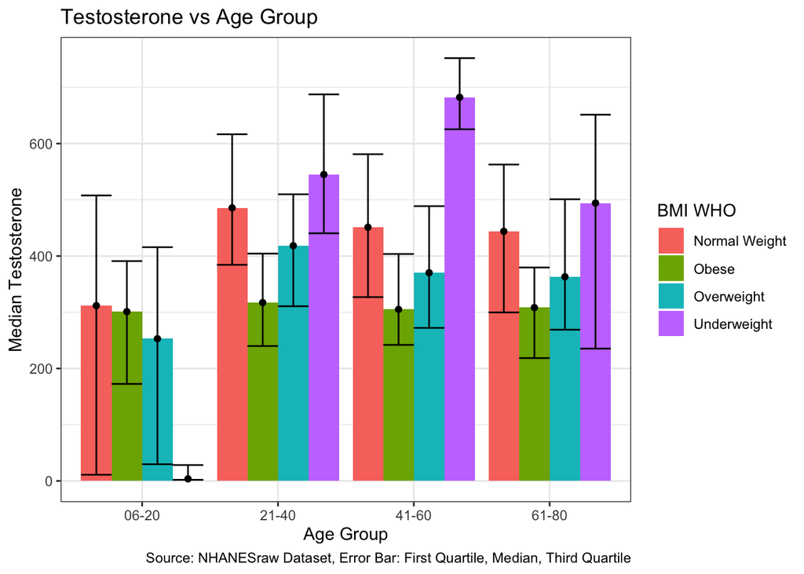

- Age is grouped into approximately twenty year increments starting at the first age recorded for testosterone which is six years

# 3. How does poverty ratio relate to BMI and cholesterol levels across races?

## Poverty vs BMI faceted by Race

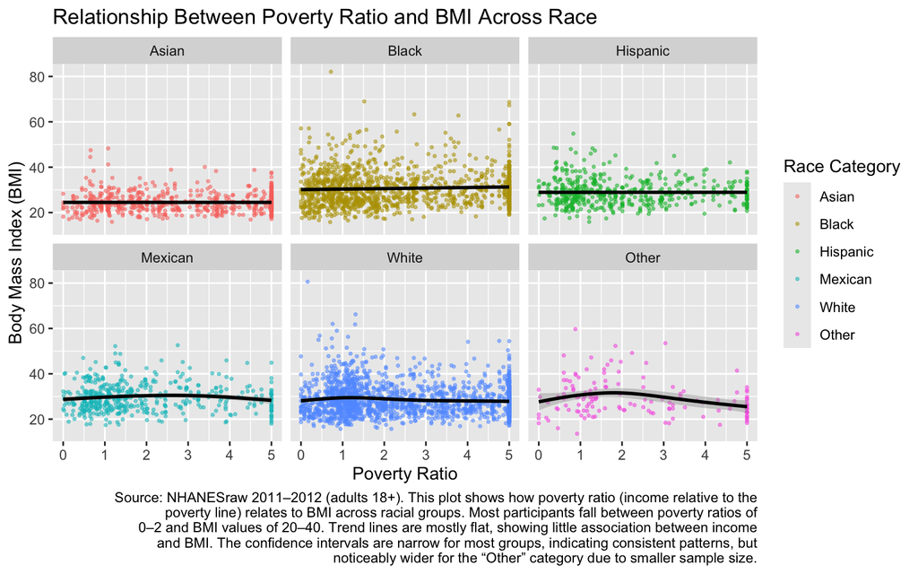

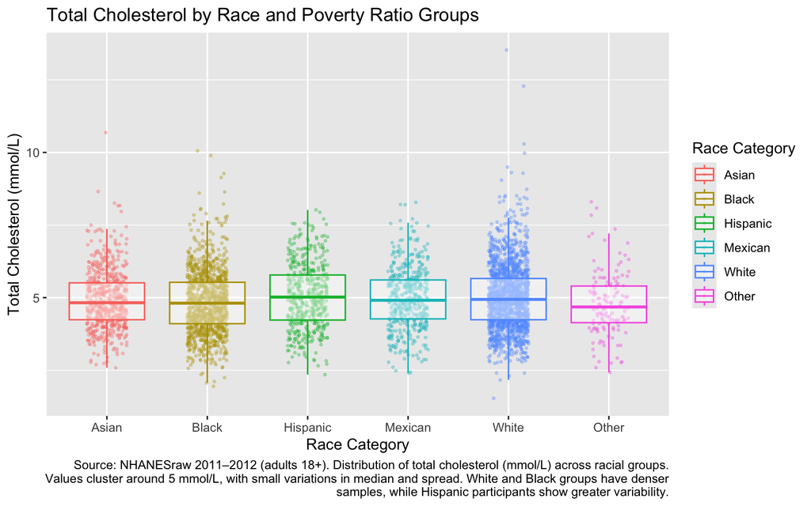

# 4. To what extent is education associated with the age when participants first begin smoking or using marijuana regularly, and does this vary by gender?

## Smoking vs Education faceted by Gender

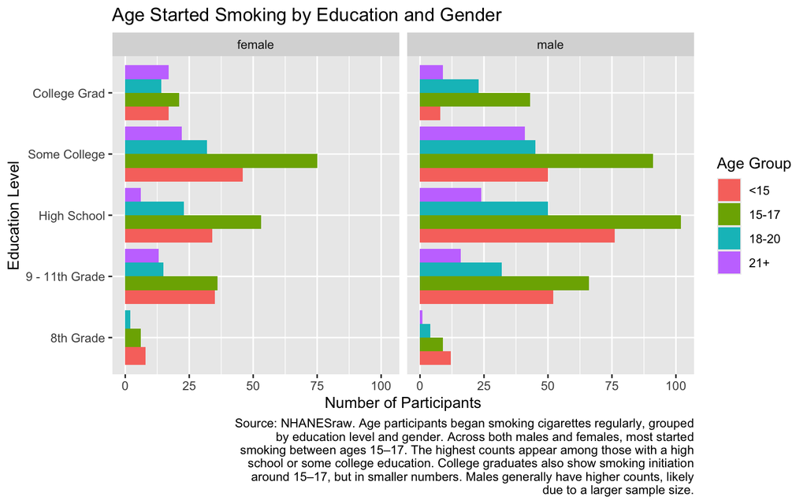

## Marijuana vs Education faceted by Gender

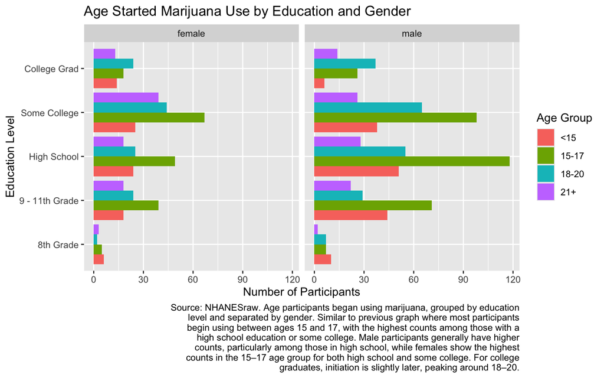

- To analyze the relationship between the age participants first used cigarettes or used marijuana and education, selected variables included education, gender, SmokeAge, and AgeRegMarij, removing any missing values. Age variables were grouped into categories (<15, 15–17, 18–20, 21+) to help simplify the visualization and highlight trends across age ranges. Bar charts were chosen because they effectively display the distribution of a subgroup across categories. In this case, two discrete variables are grouped by a third discrete variable, and dodge-positioned bars allow for direct comparison of age groups within each education level. The plots were faceted by gender to explore potential differences between males and females. Across both cigarettes and marijuana, most participants started between ages 15–17, with high frequencies for individuals with a high school education or some college. College graduates also report starting in this age range, but in smaller numbers. Male participants generally have higher frequencies, particularly in the high school category, while females show the highest counts for some college education. For cigarette and marijuana use, the 8th grade education level has <15 age group as the highest bar. Very early smoking age (<15) is more common for cigarette use than marijuana where the <15 age group is the second-highest age group in some college, high school, and 9th–11th grade groups. For marijuana, the <15 age group is lower across all education levels, indicating that fewer participants start marijuana use very early compared to cigarettes. Overall, the age participants first used cigarettes or used marijuana began in mid-teens (15–17). Among these, males typically finished high school, while females most often reached some college. Future analysis could focus on how these patterns relate to health outcomes later in life. It could also explore whether starting age correlates with race or socioeconomic status.